# Informe Mortalidad USA

## Índice

- 1. Librerías
- 2. Limpieza de datos
- 3. Comparación porcentual 1999 vs 2017
- 4. Evolución de la tasa ajustada anual
- 5. Ranking de causas por año
- 5.1 Cambios en el ranking 1999 vs 2017
- 6. Muertes por desesperación
- 7. Top 10 causas de muerte
- 8.1 Paneles de tasa ajustada por causa
- 8.1.1 Boxplots por semestre
- 8.2 Heatmap de muertes absolutas
- 8.3.1 Mapa interactivo
- 8.3.2 Tasa ajustada por estado
- 9. West Virginia – todas las causas
- 9.1 Comparación muertes 1999 vs 2017
- 9.2 West Virginia vs Promedio Nacional
- 10. Clustering K-Means
- 10.1 Preparación
- 10.2 Método del codo + Silhouette
- 10.3 Modelo K-Means
- 10.4 Visualización PCA
- 11. Modelo Predictivo ARIMA
- 11.1 Series de tiempo por causa
- 11.2 Prueba ADF
- 11.3 ACF y PACF West Virginia
- 11.4 Selección automática del modelo
- 11.5 Diagnóstico de residuos
- 11.6 Proyecciones ARIMA 2018-2022
- 11.7 Tabla de valores proyectados
- 12. Modelos adicionales
- 13. Modelo ETS
- 14. Regresión Lineal
- 15. Comparación de modelos
- 16. Justificación del modelo
- 17. Insights clave
- 18. Limitaciones del estudio
- 19. Conclusiones
- 20. Referencias

# 1. Librerías

```python
import pandas as pd
import numpy as np
import matplotlib.pyplot as plt
import matplotlib.ticker as mticker
import matplotlib.patches as mpatches
import seaborn as sns
import warnings
warnings.filterwarnings('ignore')

from scipy import stats
from IPython.display import display, HTML

# Configuración global de estilo
plt.rcParams.update({
    'figure.dpi': 120,
    'figure.facecolor': 'white',
    'axes.facecolor': 'white',
    'axes.spines.top': False,
    'axes.spines.right': False,
})

print("✓ Librerías cargadas correctamente.")
```

```
✓ Librerías cargadas correctamente.
```

# 2. Limpieza de datos

```python
FILE = r"C:\Users\luisc\proyecto-mortalidad\NCHS_-_Leading_Causes_of_Death__United_States_20260227.csv"
df_raw = pd.read_csv(FILE)
print(f"Shape original: {df_raw.shape}")

# Limpiar nombres de columnas
df_raw.columns = (
    df_raw.columns.str.strip().str.lower()
    .str.replace(' ', '_').str.replace('-', '_')
)

# Renombrar columnas clave
rename_map = {
    'year'                 : 'anio',
    '113_cause_name'       : 'causa_codigo',
    'cause_name'           : 'causa',
    'state'                : 'estado',
    'deaths'               : 'muertes',
    'age_adjusted_death_rate': 'tasa_ajustada'
}
rename_map = {k: v for k, v in rename_map.items() if k in df_raw.columns}
df = df_raw.rename(columns=rename_map).copy()

# Convertir tipos
df['muertes']      = pd.to_numeric(df['muertes'].astype(str).str.replace(',', '', regex=False), errors='coerce')
df['tasa_ajustada']= pd.to_numeric(df['tasa_ajustada'].astype(str).str.replace(',', '.', regex=False), errors='coerce')
df['anio']         = pd.to_numeric(df['anio'], errors='coerce')
```

```
Shape original: (10868, 6)
```

# 3. Comparación porcentual 1999 vs 2017

```
Totales nacionales por año:
 anio  muertes
 2014      NaN
 2016      NaN
 2017      NaN
 2013      NaN
 2012      NaN
 2015      NaN
 2011      NaN
 2010      NaN
 2009      NaN
 2008      NaN
 2007      NaN
 2006      NaN
 2004      NaN
 2005      NaN
 2003      NaN
 2002      NaN
 2001      NaN
 2000      NaN
 1999      NaN

Total acumulado por causa (1999–2017):
                  causa  total_1999_2017
          Heart disease        12222.640
                 Cancer        10843.644
                 Stroke         2726.523
                   CLRD         2594.927
 Unintentional injuries         2347.820
    Alzheimer's disease         1494.816
               Diabetes         1399.943
Influenza and pneumonia         1094.641
         Kidney disease          858.613
                Suicide          697.016
```

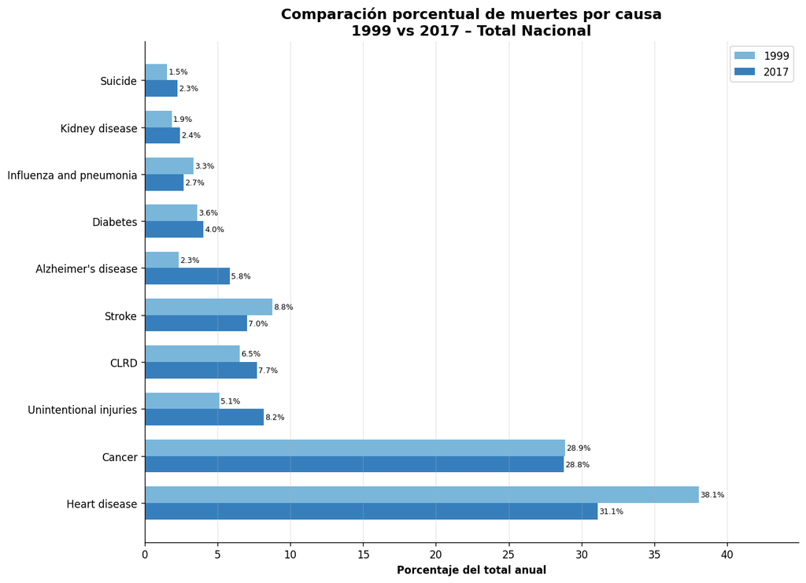

```python
# Dataset nacional (United States, 1999–2017)
datos = df[
    (df['estado'] == 'United States') &
    (df['anio'] >= 1999) & (df['anio'] <= 2017)
][['anio', 'causa', 'muertes', 'tasa_ajustada']].copy()

# Dataset por estados (excluir United States)
datos_estados = df[
    (df['estado'] != 'United States') &
    (df['anio'] >= 1999) & (df['anio'] <= 2017)
].copy()

# Totales nacionales por año
totales_anuales = datos[datos['causa'] == 'All causes'][['anio', 'muertes']].copy()
print("\nTotales nacionales por año:")
print(totales_anuales.to_string(index=False))

# Total acumulado por causa
totales_causa = (
    datos[datos['causa'] != 'All causes']
    .groupby('causa')['muertes'].sum()
    .sort_values(ascending=False)
    .reset_index(name='total_1999_2017')
)
print("\nTotal acumulado por causa (1999–2017):")
print(totales_causa.to_string(index=False))
datos_comp = datos[
    (datos['anio'].isin([1999, 2017])) & (datos['causa'] != 'All causes')
].copy()
datos_comp['total_anual'] = datos_comp.groupby('anio')['muertes'].transform('sum')
datos_comp['porcentaje']  = datos_comp['muertes'] / datos_comp['total_anual'] * 100

orden_causas = (
    datos_comp[datos_comp['anio'] == 2017]
    .sort_values('porcentaje', ascending=False)['causa'].tolist()
)
pivot = datos_comp.pivot(index='causa', columns='anio', values='porcentaje').loc[orden_causas]

fig, ax = plt.subplots(figsize=(11, 8))
y = np.arange(len(pivot))
h = 0.35
bars1 = ax.barh(y + h/2, pivot[1999], h, label='1999', color='#6baed6', alpha=0.9)
bars2 = ax.barh(y - h/2, pivot[2017], h, label='2017', color='#2171b5', alpha=0.9)
for bar in list(bars1) + list(bars2):
    w = bar.get_width()
    ax.text(w + 0.1, bar.get_y() + bar.get_height()/2, f'{w:.1f}%', va='center', fontsize=7.5)
ax.set_yticks(y)
ax.set_yticklabels(pivot.index, fontsize=10)
ax.set_xlabel('Porcentaje del total anual', fontweight='bold')
ax.set_title('Comparación porcentual de muertes por causa\n1999 vs 2017 – Total Nacional', fontsize=14, fontweight='bold')
ax.legend()
ax.grid(axis='x', alpha=0.3)
ax.set_xlim(0, pivot.max().max() * 1.18)
plt.tight_layout()
plt.show()
```

# 4. Evolución de la tasa ajustada anual

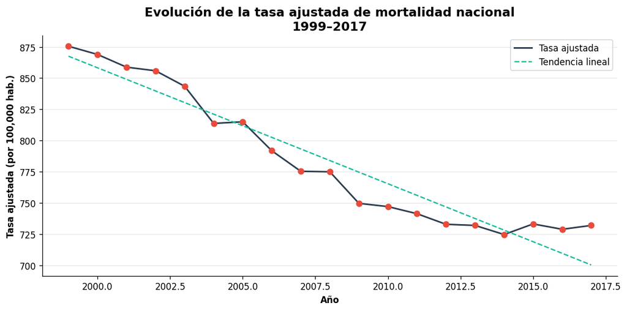

```python
total_anual = datos[datos['causa'] == 'All causes'].sort_values('anio')

fig, ax = plt.subplots(figsize=(10, 5))
ax.plot(total_anual['anio'], total_anual['tasa_ajustada'], color='#2C3E50', linewidth=1.8, label='Tasa ajustada')
ax.scatter(total_anual['anio'], total_anual['tasa_ajustada'], color='#E74C3C', s=40, zorder=5)

slope, intercept, *_ = stats.linregress(total_anual['anio'], total_anual['tasa_ajustada'])
x_fit = np.array([1999, 2017])
ax.plot(x_fit, slope * x_fit + intercept, color='#18BC9C', linestyle='--', linewidth=1.5, label='Tendencia lineal')

ax.yaxis.set_major_formatter(mticker.FuncFormatter(lambda x, _: f'{x:,.0f}'))
ax.set_xlabel('Año', fontweight='bold')
ax.set_ylabel('Tasa ajustada (por 100,000 hab.)', fontweight='bold')
ax.set_title('Evolución de la tasa ajustada de mortalidad nacional\n1999–2017', fontsize=14, fontweight='bold')
ax.legend()
ax.grid(axis='y', alpha=0.3)
plt.tight_layout()
plt.show()
```

# 5. Ranking de causas por año

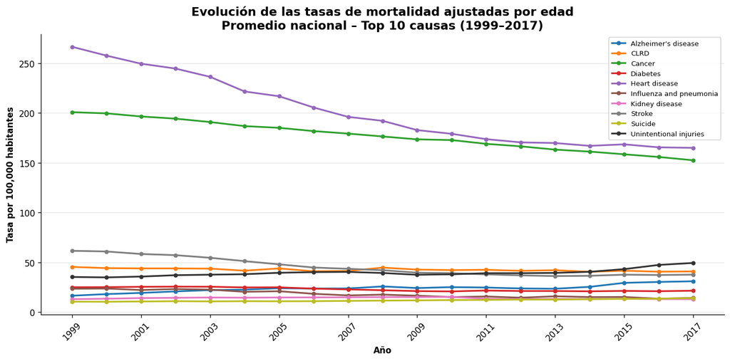

```python
top10_tasas = (
    datos[datos['causa'] != 'All causes']
    .groupby('causa')['tasa_ajustada'].mean()
    .nlargest(10).index.tolist()
)
datos_tasas_nac = (
    datos[datos['causa'].isin(top10_tasas)]
    .groupby(['anio', 'causa'], as_index=False)['tasa_ajustada'].mean()
    .rename(columns={'tasa_ajustada': 'tasa_nac'})
)
base_colors  = [plt.cm.tab10(i) for i in range(9)] + [(0.2, 0.2, 0.2, 1)]
causas_ord   = sorted(datos_tasas_nac['causa'].unique())
color_map    = dict(zip(causas_ord, base_colors[:len(causas_ord)]))

fig, ax = plt.subplots(figsize=(12, 6))
for causa, grp in datos_tasas_nac.groupby('causa'):
    ax.plot(grp['anio'], grp['tasa_nac'], label=causa, color=color_map[causa], linewidth=2, marker='o', markersize=4)
ax.set_xticks(range(1999, 2018, 2))
ax.tick_params(axis='x', rotation=45)
ax.set_xlabel('Año', fontweight='bold')
ax.set_ylabel('Tasa por 100,000 habitantes', fontweight='bold')
ax.set_title('Evolución de las tasas de mortalidad ajustadas por edad\nPromedio nacional – Top 10 causas (1999–2017)', fontsize=14, fontweight='bold')
ax.legend(fontsize=8, loc='upper right', framealpha=0.8)
ax.grid(axis='y', alpha=0.3)
plt.tight_layout()
plt.show()
```

## 5.1 Cambios en el ranking 1999 vs 2017

```python
datos_nacional = datos[datos['causa'] != 'All causes'].copy()
datos_nacional['rank'] = datos_nacional.groupby('anio')['muertes'].rank(ascending=False, method='min').astype(int)

def get_rank(year):
    return (
        datos_nacional[datos_nacional['anio'] == year][['causa', 'rank', 'muertes']]
        .rename(columns={'rank': f'rank_{year}', 'muertes': f'muertes_{year}'})
    )

cambios = get_rank(1999).merge(get_rank(2017), on='causa')
cambios['cambio_rank'] = cambios['rank_2017'] - cambios['rank_1999']
cambios['pct_cambio']  = ((cambios['muertes_2017'] - cambios['muertes_1999']) / cambios['muertes_1999'] * 100).round(1)
cambios['cambio_fmt']  = cambios['cambio_rank'].apply(
    lambda x: f'▲{abs(int(x))}' if x < 0 else (f'▼{int(x)}' if x > 0 else '=')
)
tabla_cambios = (
    cambios[['causa', 'rank_1999', 'rank_2017', 'cambio_fmt', 'pct_cambio']]
    .sort_values('rank_1999')
    .rename(columns={'causa': 'Causa', 'rank_1999': 'Rank 1999',
                     'rank_2017': 'Rank 2017', 'cambio_fmt': 'Cambio', 'pct_cambio': 'Variación %'})
)

def colorear_tabla(df):
    def cc(val): return 'color: green; font-weight: bold' if '▲' in str(val) else ('color: red; font-weight: bold' if '▼' in str(val) else '')
    def cp(val):
        try: v = float(val); return f'color: {"red" if v > 0 else "green"}; {"font-weight:bold" if abs(v) > 10 else ""}'
        except: return ''
    return (df.style.map(cc, subset=['Cambio']).map(cp, subset=['Variación %'])
            .set_table_styles([{'selector': 'thead th', 'props': [('background-color', '#04376B'), ('color', 'white'), ('font-weight', 'bold')]}])
            .set_caption('Cambios en el ranking de causas de muerte (1999–2017)').hide(axis='index'))

display(colorear_tabla(tabla_cambios))
```

Cambios en el ranking de causas de muerte (1999–2017)

| Causa | Rank 1999 | Rank 2017 | Cambio | Variación % |
| --- | --- | --- | --- | --- |
| Heart disease | 1 | 1 | = | -10.700000 |
| Cancer | 2 | 2 | = | 9.000000 |
| Stroke | 3 | 5 | ▼2 | -12.500000 |
| CLRD | 4 | 4 | = | 29.000000 |
| Unintentional injuries | 5 | 3 | ▲2 | 73.700000 |
| Diabetes | 6 | 7 | ▼1 | 22.200000 |
| Influenza and pneumonia | 7 | 8 | ▼1 | -12.600000 |
| Alzheimer's disease | 8 | 6 | ▲2 | 172.600000 |
| Kidney disease | 9 | 9 | = | 42.500000 |
| Suicide | 10 | 10 | = | 61.600000 |

# 6. Muertes por desesperación

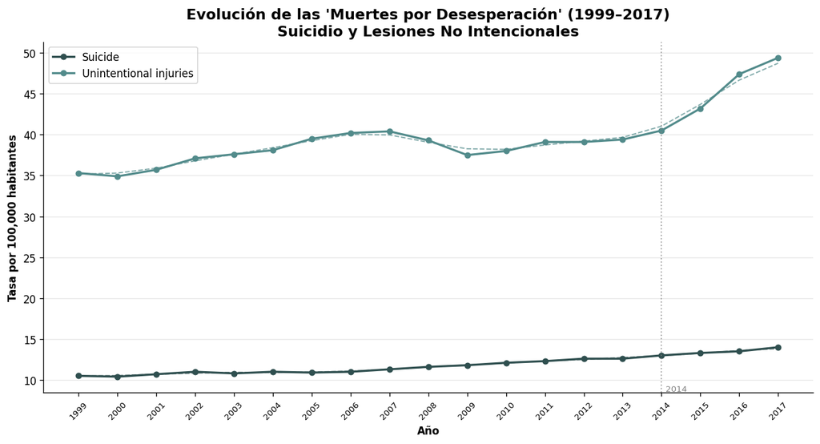

```python
from scipy.ndimage import uniform_filter1d

causas_d = ['Suicide', 'Unintentional injuries']
datos_d  = datos_nacional[datos_nacional['causa'].isin(causas_d)].copy()
datos_d['anio'] = datos_d['anio'].astype(int)
colors_d = {'Suicide': '#2F4F4F', 'Unintentional injuries': '#528B8B'}

fig, ax = plt.subplots(figsize=(11, 6))
for causa, grp in datos_d.groupby('causa'):
    grp   = grp.sort_values('anio')
    ax.plot(grp['anio'], grp['tasa_ajustada'], color=colors_d[causa], linewidth=2, marker='o', markersize=5, label=causa)
    suave = uniform_filter1d(grp['tasa_ajustada'].values, size=3)
    ax.plot(grp['anio'], suave, color=colors_d[causa], linestyle='--', linewidth=1.2, alpha=0.7)
ax.axvline(2014, color='gray', linestyle=':', linewidth=1.2, alpha=0.7)
ax.text(2014.1, ax.get_ylim()[0] * 1.02, '2014', color='gray', fontsize=8)
ax.set_xticks(range(1999, 2018))
ax.tick_params(axis='x', rotation=45, labelsize=8)
ax.set_xlabel('Año', fontweight='bold')
ax.set_ylabel('Tasa por 100,000 habitantes', fontweight='bold')
ax.set_title("Evolución de las 'Muertes por Desesperación' (1999–2017)\nSuicidio y Lesiones No Intencionales", fontsize=14, fontweight='bold')
ax.legend(loc='upper left')
ax.grid(axis='y', alpha=0.3)
plt.tight_layout()
plt.show()
```

# 7. Top 10 causas de muerte

[figure not shown]

```python
top10 = pd.DataFrame({
    'causa': ['Heart disease', 'Cancer', 'Unintentional injuries', 'CLRD', 'Stroke',
              'Diabetes', "Alzheimer's disease", 'Kidney disease', 'Influenza and pneumonia', 'Suicide'],
    'total_muertes': [326637, 281998, 247735, 207523, 192144, 170364, 144783, 143719, 53128, 48875]
})
top10_ord   = top10.sort_values('total_muertes').copy()
norm        = plt.Normalize(top10_ord['total_muertes'].min(), top10_ord['total_muertes'].max())
colors_bar  = [plt.cm.Blues(0.35 + 0.65 * norm(v)) for v in top10_ord['total_muertes']]

fig, ax = plt.subplots(figsize=(11, 7))
bars = ax.barh(top10_ord['causa'], top10_ord['total_muertes'], color=colors_bar, height=0.7)
for bar, val in zip(bars, top10_ord['total_muertes']):
    ax.text(val + 1500, bar.get_y() + bar.get_height()/2, f'{val:,}', va='center', fontweight='bold', fontsize=9)
ax.set_xlabel('Número de Muertes', fontweight='bold')
ax.set_title('Top 10 Causas de Muerte en EE.UU.\nTotal acumulado de muertes (1999–2017)', fontsize=14, fontweight='bold')
ax.xaxis.set_major_formatter(mticker.FuncFormatter(lambda x, _: f'{x/1e3:.0f}K'))
ax.set_xlim(0, top10_ord['total_muertes'].max() * 1.18)
ax.grid(axis='x', alpha=0.3)
plt.tight_layout()
plt.show()
```

## 8.1 Paneles de tasa ajustada por causa

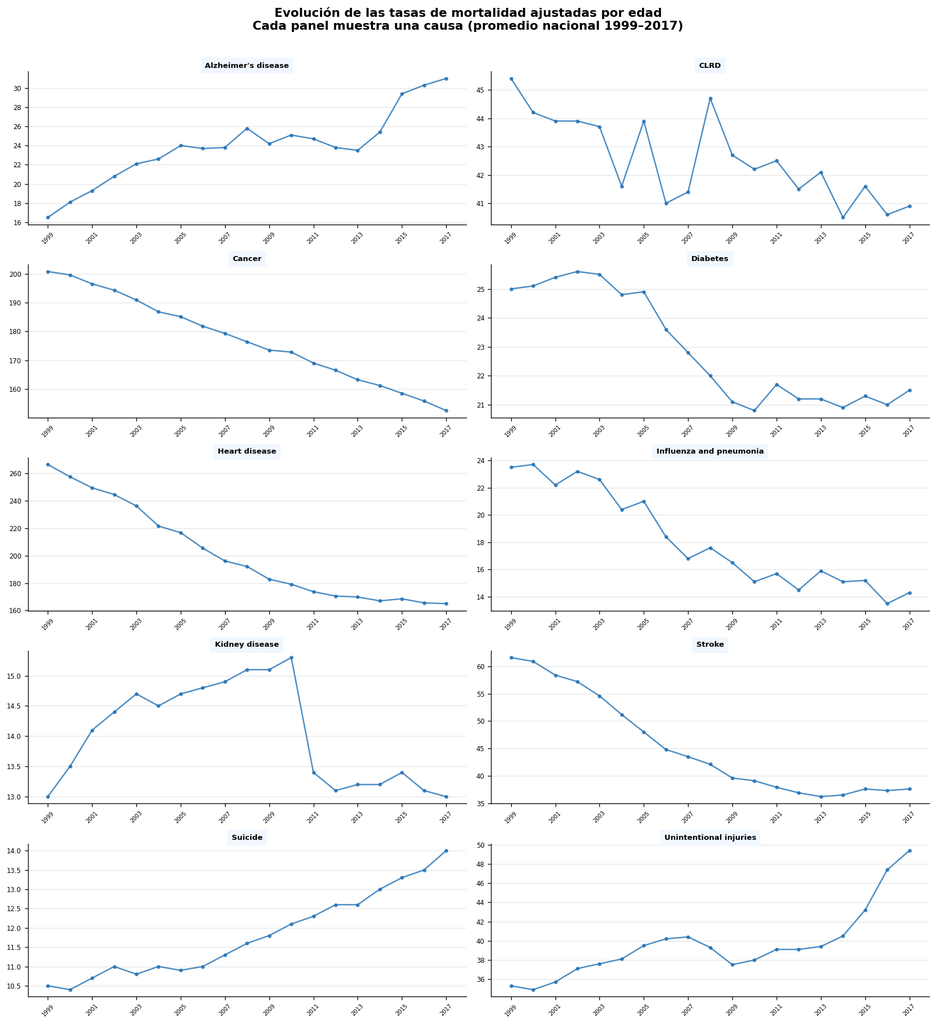

```python
tasas_nac = (
    datos[datos['causa'] != 'All causes']
    .groupby(['anio', 'causa'], as_index=False)['tasa_ajustada'].mean()
)
causas_u = sorted(tasas_nac['causa'].unique())
n = len(causas_u)
ncols = 2
nrows = (n + 1) // ncols

fig, axes = plt.subplots(nrows, ncols, figsize=(14, nrows * 3))
axes = axes.flatten()
for i, causa in enumerate(causas_u):
    ax  = axes[i]
    sub = tasas_nac[tasas_nac['causa'] == causa].sort_values('anio')
    ax.plot(sub['anio'], sub['tasa_ajustada'], color='#2171B5', linewidth=1.5, marker='o', markersize=3, alpha=0.8)
    ax.set_title(causa, fontweight='bold', fontsize=8, backgroundcolor='#F0F7FF', pad=4)
    ax.set_xticks(range(1999, 2018, 2))
    ax.tick_params(axis='x', rotation=45, labelsize=6)
    ax.tick_params(axis='y', labelsize=7)
    ax.grid(axis='y', alpha=0.3)
    ax.spines['top'].set_visible(False)
    ax.spines['right'].set_visible(False)
for j in range(i + 1, len(axes)):
    axes[j].set_visible(False)
fig.suptitle('Evolución de las tasas de mortalidad ajustadas por edad\nCada panel muestra una causa (promedio nacional 1999–2017)', fontsize=13, fontweight='bold', y=1.01)
plt.tight_layout()
plt.show()
```

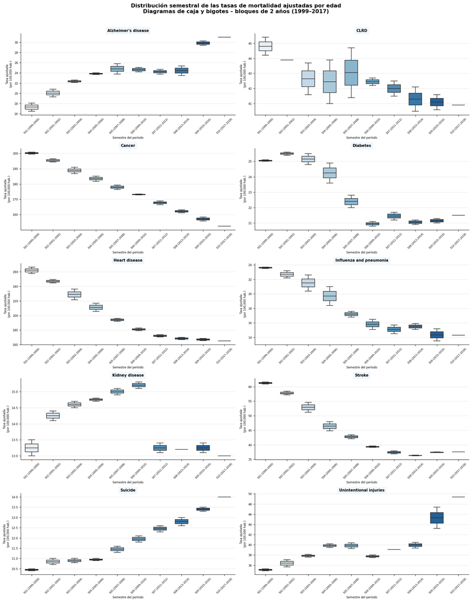

```python
def asignar_semestre(anio):
    bloque = (anio - 1999) // 2 + 1
    inicio = 1999 + (bloque - 1) * 2
    fin    = inicio + 1
    return f"S{bloque:02d} ({inicio}–{fin})"

tasas_box = tasas_nac.copy()
tasas_box['semestre'] = tasas_box['anio'].apply(asignar_semestre)
orden_sem = sorted(tasas_box['semestre'].unique(), key=lambda x: int(x.split('S')[1].split(' ')[0]))

fig, axes = plt.subplots(nrows, ncols, figsize=(16, nrows * 4))
axes = axes.flatten()
for i, causa in enumerate(causas_u):
    ax  = axes[i]
    sub = tasas_box[tasas_box['causa'] == causa]
    sns.boxplot(data=sub, x='semestre', y='tasa_ajustada', order=orden_sem, ax=ax,
                palette='Blues', width=0.6, linewidth=1.2,
                flierprops=dict(marker='o', markerfacecolor='#E74C3C', markersize=4))
    ax.set_title(causa, fontweight='bold', fontsize=9, backgroundcolor='#F0F7FF', pad=4)
    ax.set_xlabel('Semestre del período', fontsize=7)
    ax.set_ylabel('Tasa ajustada\n(por 100,000 hab.)', fontsize=7)
    ax.tick_params(axis='x', rotation=45, labelsize=6)
    ax.tick_params(axis='y', labelsize=7)
    ax.grid(axis='y', alpha=0.3)
    ax.spines['top'].set_visible(False)
    ax.spines['right'].set_visible(False)
for j in range(i + 1, len(axes)):
    axes[j].set_visible(False)
fig.suptitle('Distribución semestral de las tasas de mortalidad ajustadas por edad\nDiagramas de caja y bigotes – bloques de 2 años (1999–2017)', fontsize=13, fontweight='bold', y=1.01)
plt.tight_layout()
plt.show()

# Interpretación:
# Los diagramas de caja y bigotes permiten observar cómo varía la dispersión de las tasas
# de mortalidad para cada causa a lo largo del período. Las enfermedades cardíacas presentan
# una mediana decreciente con dispersión reducida en los semestres más recientes, mientras que
# las lesiones no intencionales muestran aumento progresivo de la mediana, coherente con la
# crisis de opioides.
```

## 8.2 Heatmap de muertes absolutas

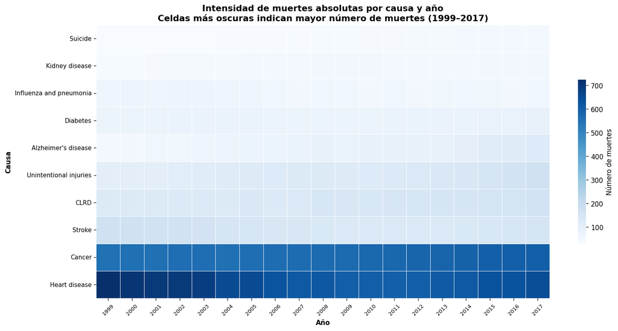

```python
pivot_heat = (
    datos[datos['causa'] != 'All causes']
    .pivot(index='causa', columns='anio', values='muertes')
)
pivot_heat = pivot_heat.loc[pivot_heat.sum(axis=1).sort_values().index]

fig, ax = plt.subplots(figsize=(14, 7))
sns.heatmap(pivot_heat, cmap='Blues', ax=ax, linewidths=0.3, linecolor='white',
            cbar_kws={'label': 'Número de muertes', 'shrink': 0.6})
ax.set_title('Intensidad de muertes absolutas por causa y año\nCeldas más oscuras indican mayor número de muertes (1999–2017)', fontsize=13, fontweight='bold')
ax.set_xlabel('Año', fontweight='bold')
ax.set_ylabel('Causa', fontweight='bold')
ax.tick_params(axis='x', rotation=45, labelsize=8)
ax.tick_params(axis='y', labelsize=9)
plt.tight_layout()
plt.show()
```

### 8.3.1 Mapa interactivo

```python
import plotly.express as px

abbrev = {
    'Alabama': 'AL', 'Alaska': 'AK', 'Arizona': 'AZ', 'Arkansas': 'AR',
    'California': 'CA', 'Colorado': 'CO', 'Connecticut': 'CT', 'Delaware': 'DE',
    'Florida': 'FL', 'Georgia': 'GA', 'Hawaii': 'HI', 'Idaho': 'ID',
    'Illinois': 'IL', 'Indiana': 'IN', 'Iowa': 'IA', 'Kansas': 'KS',
    'Kentucky': 'KY', 'Louisiana': 'LA', 'Maine': 'ME', 'Maryland': 'MD',
    'Massachusetts': 'MA', 'Michigan': 'MI', 'Minnesota': 'MN', 'Mississippi': 'MS',
    'Missouri': 'MO', 'Montana': 'MT', 'Nebraska': 'NE', 'Nevada': 'NV',
    'New Hampshire': 'NH', 'New Jersey': 'NJ', 'New Mexico': 'NM', 'New York': 'NY',
    'North Carolina': 'NC', 'North Dakota': 'ND', 'Ohio': 'OH', 'Oklahoma': 'OK',
    'Oregon': 'OR', 'Pennsylvania': 'PA', 'Rhode Island': 'RI', 'South Carolina': 'SC',
    'South Dakota': 'SD', 'Tennessee': 'TN', 'Texas': 'TX', 'Utah': 'UT',
    'Vermont': 'VT', 'Virginia': 'VA', 'Washington': 'WA', 'West Virginia': 'WV',
    'Wisconsin': 'WI', 'Wyoming': 'WY', 'District of Columbia': 'DC'
}

mapa_muertes = datos_estados[
    (datos_estados['causa'] == 'All causes') & (datos_estados['estado'].notna())
][['anio', 'estado', 'muertes']].dropna().copy()
mapa_muertes['anio']   = mapa_muertes['anio'].astype(int)
mapa_muertes['codigo'] = mapa_muertes['estado'].map(abbrev)
mapa_muertes = mapa_muertes.dropna(subset=['codigo'])

fig_map = px.choropleth(
    mapa_muertes, locations='codigo', locationmode='USA-states',
    color='muertes', animation_frame='anio', color_continuous_scale='Blues',
    scope='usa', hover_name='estado',
    hover_data={'muertes': ':,', 'codigo': False},
    labels={'muertes': 'Número de muertes', 'anio': 'Año'},
    title='Número de muertes por estado (1999–2017)',
    range_color=[mapa_muertes['muertes'].quantile(0.02), mapa_muertes['muertes'].quantile(0.98)]
)
fig_map.update_layout(title_font_size=13, height=500,
                      geo=dict(showlakes=True, lakecolor='rgb(255,255,255)'))
fig_map.show(renderer="browser")
```

### 8.3.2 Tasa ajustada por estado

```python
mapa_tasas = datos_estados[
    (datos_estados['causa'] == 'All causes') & (datos_estados['estado'].notna())
][['anio', 'estado', 'tasa_ajustada']].dropna().copy()
mapa_tasas['anio']   = mapa_tasas['anio'].astype(int)
mapa_tasas['codigo'] = mapa_tasas['estado'].map(abbrev)
mapa_tasas = mapa_tasas.dropna(subset=['codigo'])

fig_tasas = px.choropleth(
    mapa_tasas, locations='codigo', locationmode='USA-states',
    color='tasa_ajustada', animation_frame='anio', color_continuous_scale='Reds',
    scope='usa', hover_name='estado',
    hover_data={'tasa_ajustada': ':.1f', 'codigo': False},
    labels={'tasa_ajustada': 'Tasa ajustada (por 100,000)', 'anio': 'Año'},
    title='Tasa de mortalidad ajustada por estado (1999–2017)',
    range_color=[mapa_tasas['tasa_ajustada'].quantile(0.02),
                 mapa_tasas['tasa_ajustada'].quantile(0.98)]
)
fig_tasas.update_layout(title_font_size=13, height=500,
                        geo=dict(showlakes=True, lakecolor='rgb(255,255,255)'))
fig_map.show(renderer="browser")

# Exportar a HTML para que se vea en el informe
fig_tasas.write_html("mapa_tasa_ajustada.html")
print("✓ Mapa guardado como 'mapa_tasa_ajustada.html'")
```

[output not shown]

```
✓ Mapa guardado como 'mapa_tasa_ajustada.html'
```